# Estimación Bayesiana: Primeros pasos con Brms y Stan

Héctor Nájera

04/04/2024

# Introducción

Esta nota presenta los pasos iniciales para hacer estimaciones Bayesianas en **R-Software** usando **STAN** (Hamiltonian Monte Carlo). Lo primero que tenemos que hacer es instalar la paquetería necesaria.

## Instalación de Stan

1 Ir al siguiente sitio y seguir los pasos: https://github.com/stan-dev/rstan/wiki/RStan-Getting-Started

1.1 Noten que seguramente tendran que instalar **Rtools**: https://github.com/stan-dev/rstan/wiki/Configuring-C---Toolchain-for-Windows

# Modelos

## Datos

```r
set.seed(9999)
library(MASS)
data <- data.frame(mvrnorm(n = 1000,
                 mu = c(0.5, 0, 1000),
                 Sigma = matrix(c(1, 0.7, 0.3,
                                  0.7, 1, 0.1,
                                  0.3, 0.1, 1),
                                nrow = 3)))
head(data)
```

```
##             X1          X2        X3
## 1 -0.534903942 -0.86590646  999.4466
## 2 -0.011557151 -0.41224534  998.4749
## 3  0.003044345 -0.12103473  999.2772
## 4  1.620350891  0.03936766 1000.7162
## 5 -2.092114434 -2.79748282  999.0613
## 6 -0.662023800 -0.91936626 1000.5039
```

Para ver la relación entre los datos hacemos una gráfica simple con la función `plot()`.

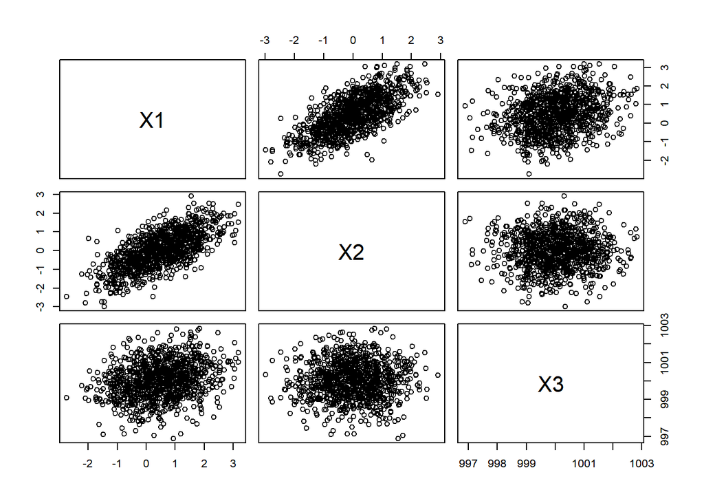

```r
plot(data)
```

Nota: Si no existiera Bayes podríamos estimar un modelo lineal con la función `lm()`. Usamos `summary()` para sintetizar nuestros resultados. Pero esto no nos interesa!

## Modelo lineal OLS

```r
summary(lm(X1~1+X2+X3, data=data))
```

```
##
## Call:
## lm(formula = X1 ~ 1 + X2 + X3, data = data)
##
## Residuals:
##      Min       1Q   Median       3Q      Max
## -2.65627 -0.45244 -0.00968  0.45007  2.48382
##
## Coefficients:
##               Estimate Std. Error t value Pr(>|t|)
## (Intercept) -248.28477   22.15750  -11.21   <2e-16 ***
## X2             0.72834    0.02276   32.00   <2e-16 ***
## X3             0.24875    0.02216   11.23   <2e-16 ***
## ---
## Signif. codes:  0 '***' 0.001 '**' 0.01 '*' 0.05 '.' 0.1 ' ' 1
##
## Residual standard error: 0.6953 on 997 degrees of freedom
## Multiple R-squared:  0.5385, Adjusted R-squared:  0.5376
## F-statistic: 581.8 on 2 and 997 DF,  p-value: < 2.2e-16
```

## Estimación bayesiana con BRMS

```r
library(brms)
library(bayesplot)
library(tidybayes)
library(ggplot2)
library(dplyr)
color_scheme_set(scheme = "viridis")
```

### Estructura de un modelo en brms

La función `brm` nos permitirá estimar modelos bayesianos de manera muy sencilla. Esta función tiene como mínimo los siguientes argumentos:

- modelo/verosimilitud: X1~ 1 + X2 + X3, family=“gaussian”
- priors: prior = c(set_prior(“normal(0,10000)”, class = “b”), set_prior(“normal(0,10000)”, class=“Intercept”), set_prior(“normal(0,1000)”, class=“sigma”)),
- datos: data=data
- MCMC: cadenas *chains=4* y número de iteraciones *iter=1000*
- cómputo: número de núcleos y de paraleización al interior con *cmdstanr*
- opcionales: valores iniciales (init), adapt.delta, max_treedepth

```
fit.brms1<-brm(X1~ 1 + X2 + X3, family="gaussian",
              prior = c(set_prior("normal(0,10000)", class = "b"),
                                      set_prior("normal(0,10000)", class="Intercept"),
                                      set_prior("normal(0,1000)", class="sigma")),
                            data=data, chains=4, cores=4, iter=1000,  threads = threading(14, grainsize = 100),backend = "cmdstanr")
```

### Prior predictive checks

Uno de los primeros pasos en estimación bayesiana es elegir los a prioris. Aunque los a prioris sean débiles, es importante conocer si los a prioris débiles van a permitir regularizar la estimación. De otra manera vamos a perder mucha eficiencia de cómputo o, peor aún, el modelo no va a tener sentido. Para hacer estos chequeos incluimos la opción `sample_prior = "only"`.

Nota: Esto no estima el modelo, i.e., no se calculan propiamente distribuciones posteriores. Lo que se hace es simplemente “simular” los valores esperados condicionando a los priors elegidos.

```r
fit.brms1<-brm(X1~ 1 + X2 + X3, family="gaussian",
              prior = c(set_prior("normal(0,10000)", class = "b"),
                                      set_prior("normal(0,10000)", class="Intercept"),
                                      set_prior("normal(0,1000)", class="sigma")),
               sample_prior = "only",
                            data=data, chains=4, cores=4, iter=1000,  threads = threading(14, grainsize = 100),backend = "cmdstanr")
```

```r
fit.brms1
```

```
##  Family: gaussian
##   Links: mu = identity; sigma = identity
## Formula: X1 ~ 1 + X2 + X3
##    Data: data (Number of observations: 1000)
##   Draws: 4 chains, each with iter = 1000; warmup = 500; thin = 1;
##          total post-warmup draws = 2000
##
## Population-Level Effects:
##             Estimate  Est.Error     l-95% CI    u-95% CI Rhat Bulk_ESS Tail_ESS
## Intercept -560896.91 9928236.59 -19974432.50 18614060.00 1.00     1652     1348
## X2           -331.33   10460.07    -20406.73    19753.85 1.00     1871     1051
## X3            560.70    9927.76    -18609.75    19959.50 1.00     1652     1348
##
## Family Specific Parameters:
##       Estimate Est.Error l-95% CI u-95% CI Rhat Bulk_ESS Tail_ESS
## sigma   801.52    586.91    34.80  2200.03 1.00     1154      734
##
## Draws were sampled using sample(hmc). For each parameter, Bulk_ESS
## and Tail_ESS are effective sample size measures, and Rhat is the potential
## scale reduction factor on split chains (at convergence, Rhat = 1).
```

### Chequeo predictivo inicial

Esos priors parecen ser exageramente débiles, llevan a producir valores que probablemente no tienen sentido.

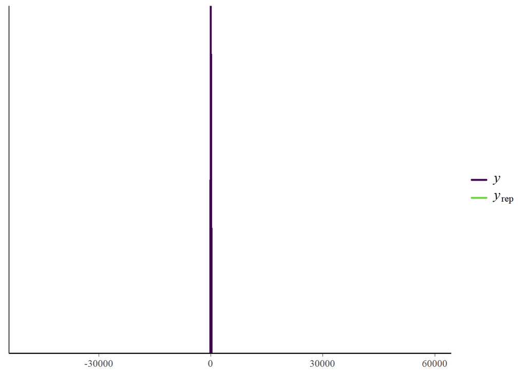

```r
pp_check(fit.brms1)
```

### Prior predictive checks 2

Ahora utilizaremos priors ligeramente más fuertes (sin llegar a ser para nada informativos).

```r
fit.brms1.1<-brm(X1~ 1 + X2 + X3, family="gaussian",
              prior = c(set_prior("normal(0,100)", class = "b"),
                                      set_prior("normal(0,100)", class="Intercept"),
                                      set_prior("normal(0,10)", class="sigma")),
               sample_prior = "only",
                            data=data, chains=4, cores=4, iter=1000,  threads = threading(14, grainsize = 100),backend = "cmdstanr")
```

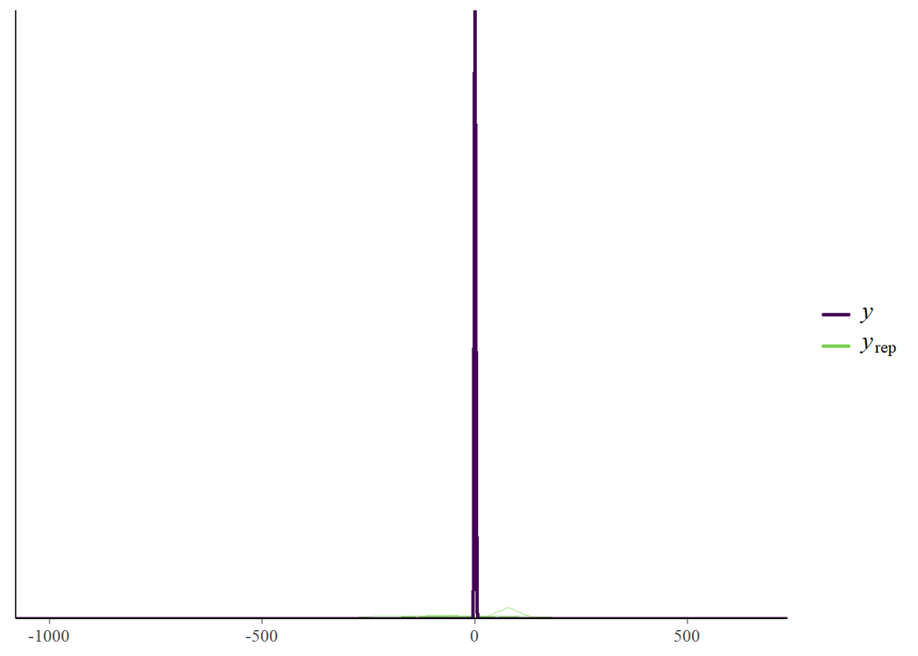

```r
pp_check(fit.brms1.1)
```

### Estimación con priors débiles.

Ahora estimamos el modelo. Removemos la opción `sample_prior = "only",`

```r
fit.brms2<-brm(X1~ 1 + X2 + X3, family="gaussian",
              prior = c(set_prior("normal(0,100)", class = "b"),
                                      set_prior("normal(0,100)", class="Intercept"),
                                      set_prior("normal(0,10)", class="sigma")),
                            data=data, chains=4, cores=4, iter=1000,  threads = threading(14, grainsize = 100),backend = "cmdstanr")
```

### Revisando la calidad de las cadenas: dos maneras `plot()` y con `bayesplot`

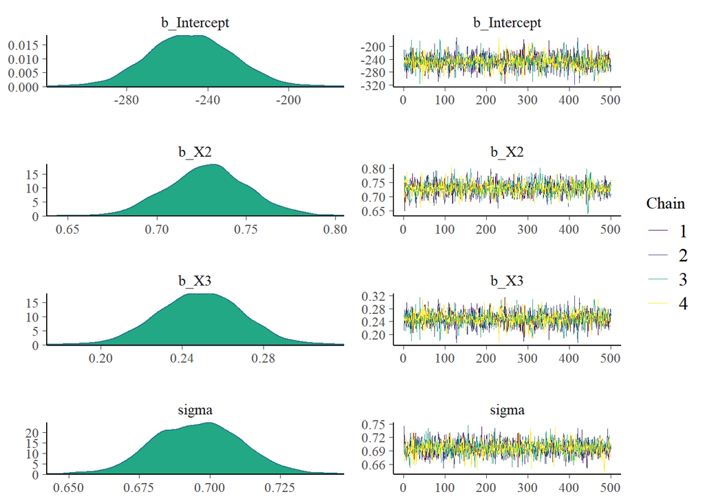

```r
plot(fit.brms2)
```

### Posterior predictive checks

La cmbinación de los a prioris y los datos nos llevan a una buena predicción.

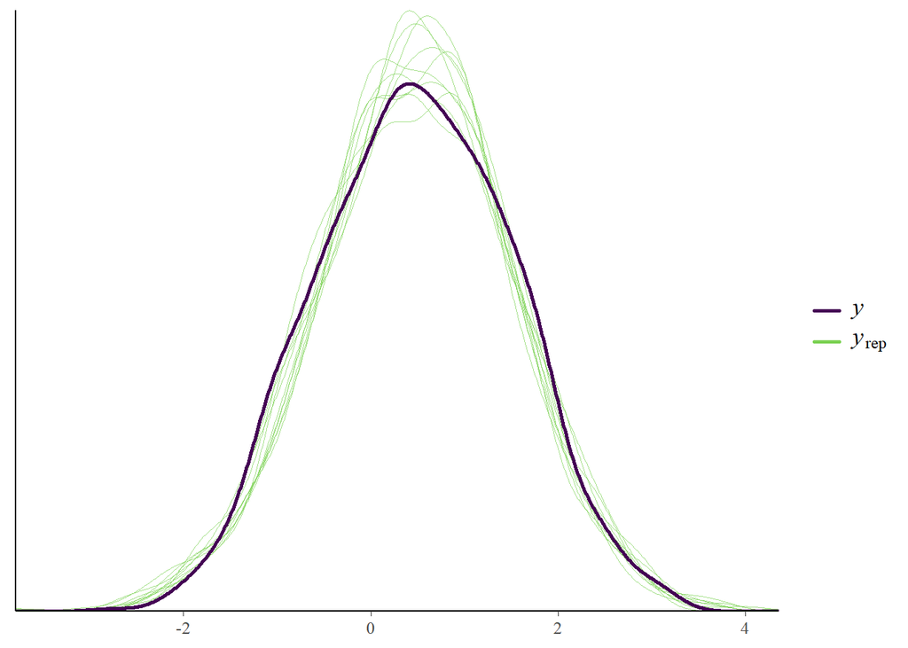

```r
pp_check(fit.brms2)
```

Ahora con bayes plot usamos la función `mcmc_trace`

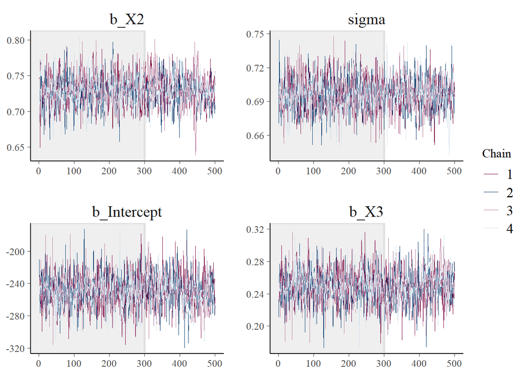

```r
plot_title <- ggtitle("Posterior distributions",
                      "with medians and 95% intervals")

color_scheme_set("mix-blue-pink")
p <- mcmc_trace(fit.brms2,  pars = c("b_X2", "sigma",  "b_Intercept", "b_X3"), n_warmup = 300,
                facet_args = list(nrow = 2))
p + facet_text(size = 15)
```

Revisando las posteriores de mis dos parámetros de interés

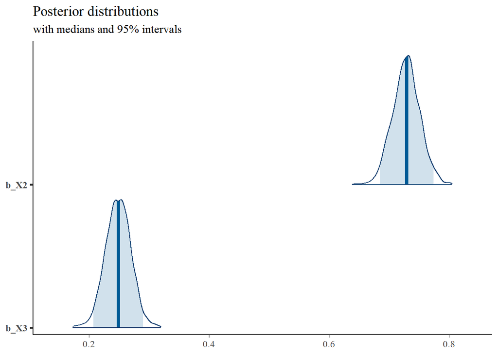

```r
mcmc_areas(fit.brms2,
           pars = c("b_X2", "b_X3"),
           prob = 0.95) + plot_title
```

Revisamos R-hat y ESS

```r
fit.brms2
```

```
##  Family: gaussian
##   Links: mu = identity; sigma = identity
## Formula: X1 ~ 1 + X2 + X3
##    Data: data (Number of observations: 1000)
##   Draws: 4 chains, each with iter = 1000; warmup = 500; thin = 1;
##          total post-warmup draws = 2000
##
## Population-Level Effects:
##           Estimate Est.Error l-95% CI u-95% CI Rhat Bulk_ESS Tail_ESS
## Intercept  -248.36     21.34  -289.92  -206.84 1.00     2301     1712
## X2            0.73      0.02     0.69     0.77 1.00     1950     1405
## X3            0.25      0.02     0.21     0.29 1.00     2303     1712
##
## Family Specific Parameters:
##       Estimate Est.Error l-95% CI u-95% CI Rhat Bulk_ESS Tail_ESS
## sigma     0.70      0.02     0.67     0.73 1.00     2151     1703
##
## Draws were sampled using sample(hmc). For each parameter, Bulk_ESS
## and Tail_ESS are effective sample size measures, and Rhat is the potential
## scale reduction factor on split chains (at convergence, Rhat = 1).
```

### BRMS: Con strong priors

```r
fit2.brms<-brm(X1~ 1 + X2 + X3, family="gaussian",
               prior = c(set_prior("normal(.7,.5)", class = "b", coef="X2"),
                         set_prior("normal(.3,.5)", class = "b", coef="X3"),
                                       set_prior("normal(0,1)", class="Intercept")),
                            data=data, chains=4, cores=4, iter=1000,  threads = threading(14, grainsize = 100),backend = "cmdstanr")
fit2.brms
```

```
##  Family: gaussian
##   Links: mu = identity; sigma = identity
## Formula: X1 ~ 1 + X2 + X3
##    Data: data (Number of observations: 1000)
##   Draws: 4 chains, each with iter = 1000; warmup = 500; thin = 1;
##          total post-warmup draws = 2000
##
## Population-Level Effects:
##           Estimate Est.Error l-95% CI u-95% CI Rhat Bulk_ESS Tail_ESS
## Intercept  -247.94     22.49  -291.53  -202.82 1.00     2654     1331
## X2            0.73      0.02     0.68     0.77 1.00     2481     1822
## X3            0.25      0.02     0.20     0.29 1.00     2652     1331
##
## Family Specific Parameters:
##       Estimate Est.Error l-95% CI u-95% CI Rhat Bulk_ESS Tail_ESS
## sigma     0.70      0.02     0.67     0.73 1.00     1949     1548
##
## Draws were sampled using sample(hmc). For each parameter, Bulk_ESS
## and Tail_ESS are effective sample size measures, and Rhat is the potential
## scale reduction factor on split chains (at convergence, Rhat = 1).
```

### Sensibilidad de los resultados a los priors

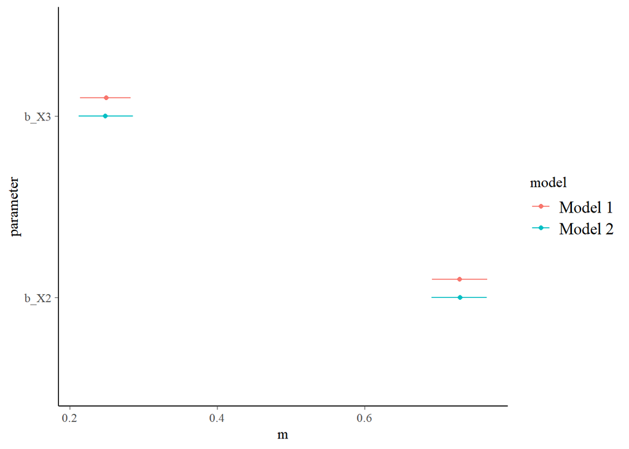

```r
combined <- rbind(mcmc_intervals_data(fit.brms2), mcmc_intervals_data(fit2.brms))
combined <- combined[c(2,3,8,9),]
combined$model <- rep(c("Model 1", "Model 2"), each = 2)

# make the plot using ggplot
library(ggplot2)
theme_set(bayesplot::theme_default())
pos <- position_nudge(y = ifelse(combined$model == "Model 2", 0, 0.1))
ggplot(combined, aes(x = m, y = parameter, color = model)) +
  geom_point(position = pos) +
  geom_linerange(aes(xmin = ll, xmax = hh), position = pos)
```

### Prior predictive checks. Notas

Una forma de checar si los priors que especificamos tienen sentido es con chequeos predictivos de los a prioris. Esto es, revisar los priors en el contexto de la verosimilitud. Para ello tenemos que incluir la opción `sample_prior="only"`. Después utilizamos `pp_check`. Esta función se utilizá después para evaluar todo el modelo.

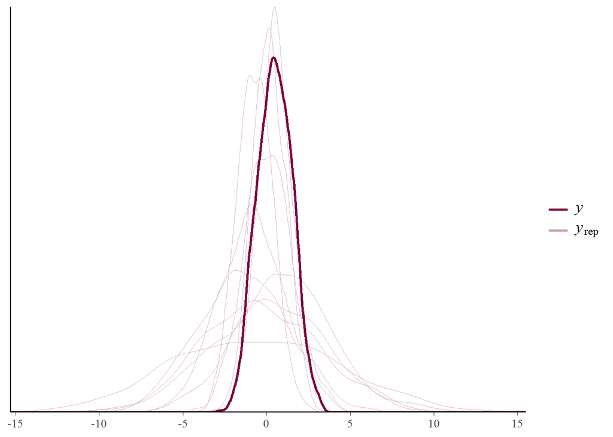

```r
fit2.brms.prior<-brm(X1~ 1 + X2 + X3,
                     sample_prior = "only",
                     family="gaussian",
               prior = c(set_prior("normal(.2,.5)", class = "b"),
                                       set_prior("normal(0,1)", class="Intercept")),
                            data=data, chains=4, cores=4, iter=1000,  threads = threading(14, grainsize = 100),backend = "cmdstanr")
pp_check(fit2.brms.prior)
```

### Posterior predictive checks

Puede mi modelo reproducir la variable dependiente?

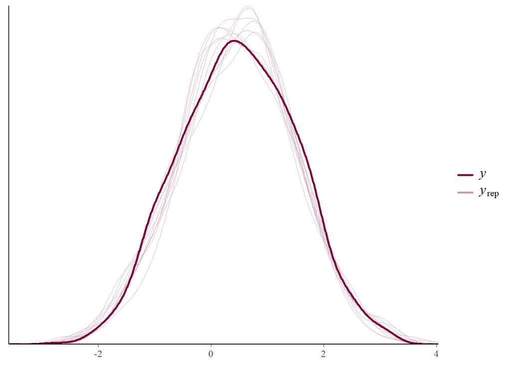

```r
pp_check(fit.brms2)
```

Y el otro?

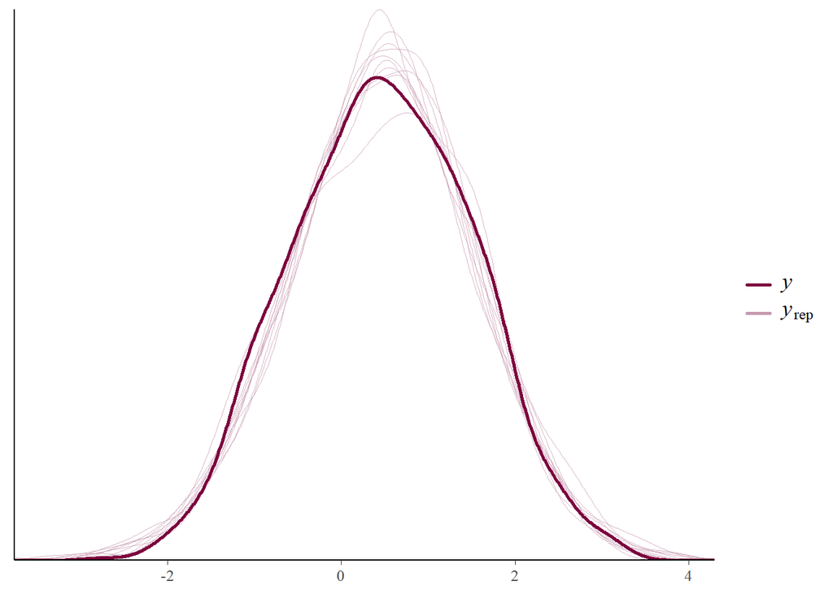

```r
pp_check(fit2.brms)
```

Diagrama de dispersión comparando la predicción

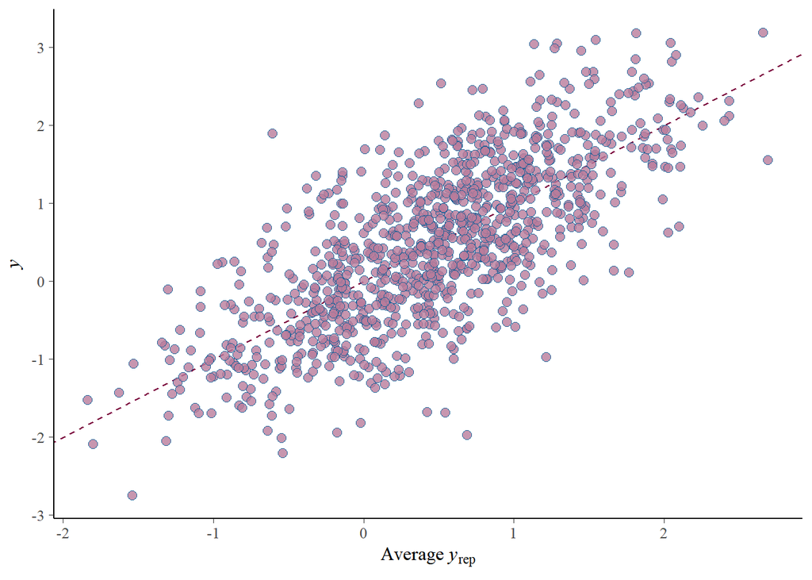

```r
ppc_scatter_avg(y = data$X1, yrep = posterior_predict(fit.brms2))
```

Son normales los errores?

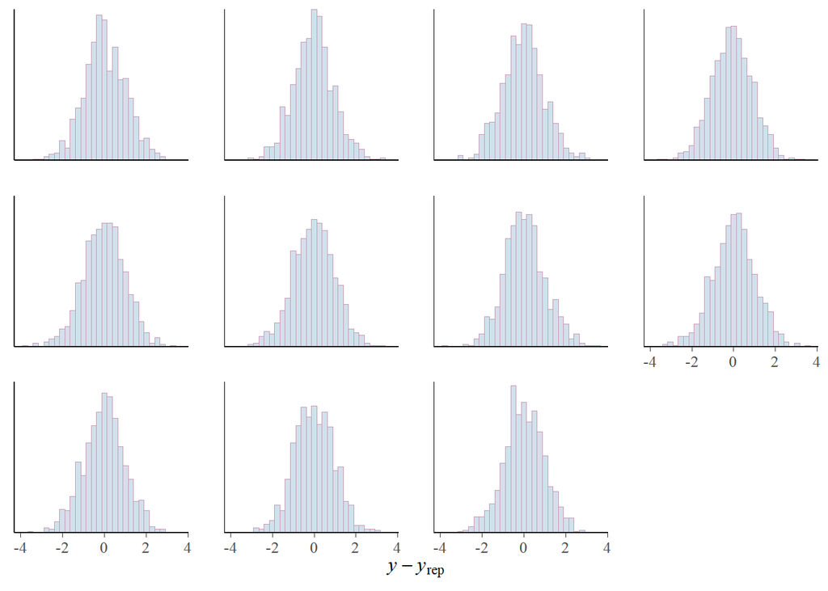

```r
pp_check(fit.brms2, type = "error_hist", nsamples = 11)
```

Qué tal si lo que me interesa es reproducir la media? Ah! Esto no sorprende mucho porque el modelo que estimamos está pensado para hacer este trabajo!

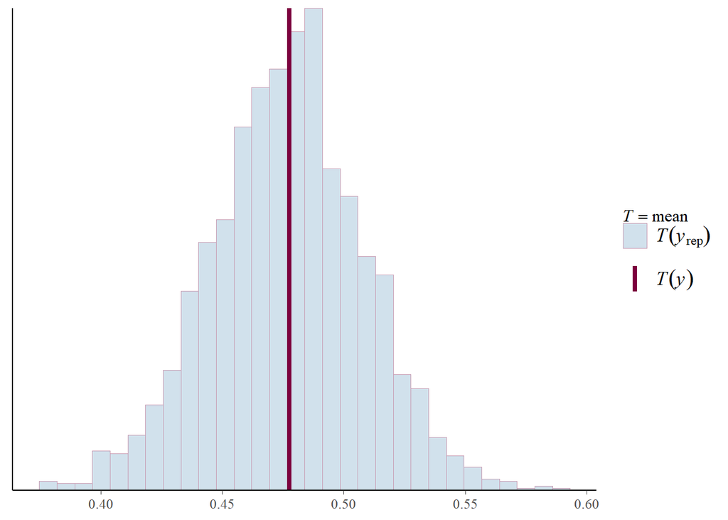

```r
pp_check(fit.brms2, type='stat', stat='mean')
```

### Hipótesis

¿Son diferentes los efectos?

```r
hypothesis(fit.brms2, "X2 = X3", alpha = 0.01)
```

```
## Hypothesis Tests for class b:
##      Hypothesis Estimate Est.Error CI.Lower CI.Upper Evid.Ratio Post.Prob Star
## 1 (X2)-(X3) = 0     0.48      0.03      0.4     0.56         NA        NA    *
## ---
## 'CI': 98%-CI for one-sided and 99%-CI for two-sided hypotheses.
## '*': For one-sided hypotheses, the posterior probability exceeds 99%;
## for two-sided hypotheses, the value tested against lies outside the 99%-CI.
## Posterior probabilities of point hypotheses assume equal prior probabilities.
```

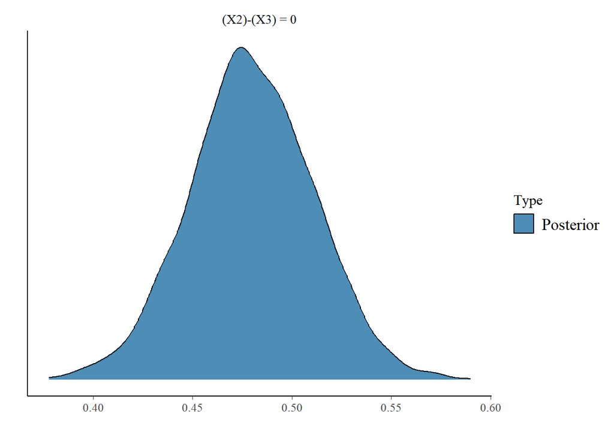

```r
plot(hypothesis(fit.brms2, "X2 = X3", alpha = 0.01))
```

```r
hypothesis(fit.brms2, "X2 + X3 <.5", alpha = 0.01)
```

```
## Hypothesis Tests for class b:
##         Hypothesis Estimate Est.Error CI.Lower CI.Upper Evid.Ratio Post.Prob
## 1 (X2+X3)-(.5) < 0     0.48      0.03      0.4     0.55          0         0
##   Star
## 1
## ---
## 'CI': 98%-CI for one-sided and 99%-CI for two-sided hypotheses.
## '*': For one-sided hypotheses, the posterior probability exceeds 99%;
## for two-sided hypotheses, the value tested against lies outside the 99%-CI.
## Posterior probabilities of point hypotheses assume equal prior probabilities.
```

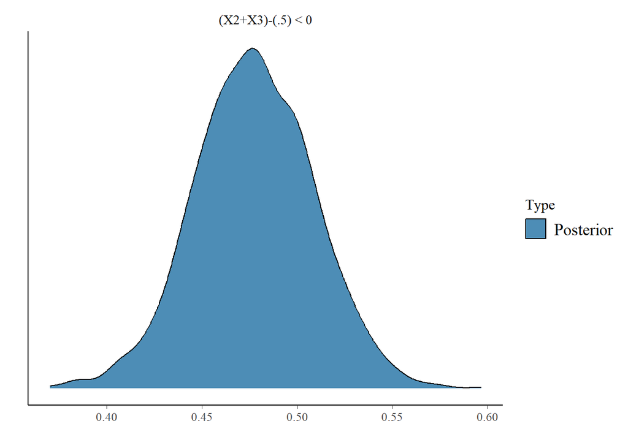

```r
plot(hypothesis(fit.brms2, "X2 + X3 <.5", alpha = 0.01))
```

### Predicción

```r
Predict<-predict(fit.brms2)
head(Predict)
```

```
##        Estimate Est.Error       Q2.5      Q97.5
## [1,] -0.3006046 0.7013654 -1.6501666  1.1212051
## [2,] -0.2378160 0.6968317 -1.6200441  1.1097869
## [3,]  0.1812663 0.6721898 -1.2112199  1.4558237
## [4,]  0.6586474 0.6846855 -0.6552041  2.0425629
## [5,] -1.7793913 0.6984120 -3.1160993 -0.3797854
## [6,] -0.1171190 0.7086947 -1.4544674  1.2664096
```

```r
Datap<-data.frame(cbind(data$X1,Predict))
head(Datap)
```

```
##             V1   Estimate Est.Error       Q2.5      Q97.5
## 1 -0.534903942 -0.3006046 0.7013654 -1.6501666  1.1212051
## 2 -0.011557151 -0.2378160 0.6968317 -1.6200441  1.1097869
## 3  0.003044345  0.1812663 0.6721898 -1.2112199  1.4558237
## 4  1.620350891  0.6586474 0.6846855 -0.6552041  2.0425629
## 5 -2.092114434 -1.7793913 0.6984120 -3.1160993 -0.3797854
## 6 -0.662023800 -0.1171190 0.7086947 -1.4544674  1.2664096
```

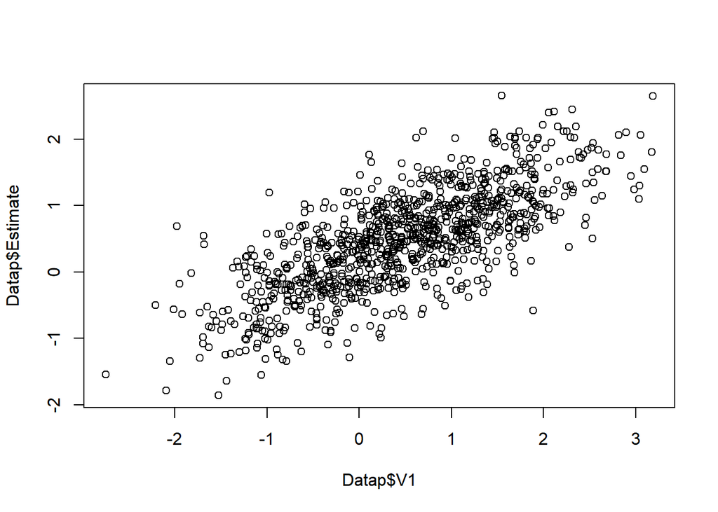

```r
plot(Datap$V1, Datap$Estimate)
```

```r
data2 <- data.frame(mvrnorm(n = 1000,
                 mu = c(0.3, 0, 9),
                 Sigma = matrix(c(1, 0.21, 0.37,
                                  0.21, 1, 0.1,
                                  0.37, 0.1, 1),
                                nrow = 3)))
```

Podemos reproducir el parámetro de interés con nuevos datos?

```r
newprediction<-predict(fit.brms2, newdata = data2, ndraws=300)
head(newprediction)
```

```
##       Estimate Est.Error      Q2.5     Q97.5
## [1,] -244.4932  20.93225 -281.4081 -202.9292
## [2,] -244.5713  20.92297 -281.9074 -203.7434
## [3,] -245.7041  20.83664 -282.1935 -203.9530
## [4,] -244.1292  20.90850 -281.5939 -202.2457
## [5,] -243.8027  20.85898 -280.4917 -202.1289
## [6,] -244.8565  20.87623 -281.4112 -203.1448
```

```r
summary(data$y)
```

```
## Length  Class   Mode
##      0   NULL   NULL
```

```r
summary(newprediction[,1])
```

```
##    Min. 1st Qu.  Median    Mean 3rd Qu.    Max.
##  -247.6  -245.3  -244.7  -244.7  -244.2  -242.0
```